# R para el modulo 2: Álgebra Lineal

Jorge de la Vega, MIDE

24/09/2022

# Temas a revisar

Los temas que revisaremos en la sesión de hoy son los siguientes:

- Vectores
- Matrices y sus operaciones
- Solución de sistemas de ecuaciones
- Ejemplos de aplicación: Cadenas de Markov
- Ejemplos de aplicación: Portfolios de inversión

Usaremos los siguientes paquetes:

- `matlib` para algunas operaciones matriciales (resolución de ecuaciones)
- `igraph` un paquete para dibujar gráficas (vértices y nodos)
- `markovchain` cálculos y gráficas asociadas con Cadenas de Markov

Los paquetes se cargarán en las secciones que se requieran, sólo para enfatizar la parte en donde se utiliza su funcionalidad.

## Vectores en R

Cuando comenzamos con el curso de R, vimos que se pueden definir vectores como en el ejemplo siguiente

```r
u <- 1:6 # números sucesivos del 1 al 6
v <- c(2,1,3,2,4,5)
coneval <- read.csv("https://raw.githubusercontent.com/jvega68/EA3/master/datos/ConevalPobreza2016.csv")
Estado <- coneval$Estado
X1 <- coneval$Población.en.situación.de.pobreza
```

Le podemos poner nombres a los componentes de un vector y llamar a sus componentes por nombre

```r
names(X1) <- Estado
X1
```

```
      Aguscalientes     Baja California Baja California Sur            Campeche
            369.652             789.109             175.642             405.035
           Coahuila              Colima             Chiapas           Chihuahua
            745.897             248.691            4113.950            1149.961
               CDMX             Durango          Guanajuato            Guerrero
           2434.424             643.299            2489.715            2314.720
            Hidalgo             Jalisco              EdoMex           Michoacán
           1478.836            2560.592            8230.200            2565.862
            Morelos             Nayarit          Nuevo León              Oaxaca
            965.852             470.130             737.765            2847.341
             Puebla           Querétaro                Qroo                 SLP
           3728.202             635.680             471.040            1267.728
            Sinaloa              Sonora             Tabasco          Tamaulipas
            929.683             831.427            1228.092            1156.220
           Tlaxcala            Veracruz             Yucatán           Zacatecas
            701.757            5049.511             901.864             780.274
```

```r
X1["CDMX"]
```

```
    CDMX
2434.424
```

Se pueden hacer las operaciones algebraicas usuales con vectores:

```r
u + v  # Suma (si tienen la misma longitud)
```

```
[1]  3  3  6  6  9 11
```

```r
2*u  # Multiplicación por un "escalar"
```

```
[1]  2  4  6  8 10 12
```

También se pueden hacer otras operaciones, pero es importante notar que estas no son parte de la definición matemática, sino del lenguaje:

```r
u*v   # producto componente a componente
```

```
[1]  2  2  9  8 20 30
```

```r
2 + v  # suma un escalar a un vector
```

```
[1] 4 3 5 4 6 7
```

```r
1:7 + v  # suma de vectores de diferente tamaño _cuidado_
```

```
[1]  3  3  6  6  9 11  9
```

```r
z <- c("rojo", "azul", "verde")  # "vectores" de caractéres o palabras.
y <- c(1, 2, 3)
names(y) <- z   # vectores con nombres
```

Y podemos definir algunas de las funciones que definieron en clase

```r
# Producto punto:
producto.punto <- function(x,y){
  sum(x*y)
}

# Norma o longitud del vector (no confundir con length, que cuenta el número de
# componentes)
norma <- function(x){
  sqrt(sum(x*x))
}

u <- c(1, 3, 4, 2, 4)
v <- c(7, 3, 56, 2, 1)
producto.punto(x = u, y = v)
```

```
[1] 248
```

```r
norma(u)
```

```
[1] 6.78233
```

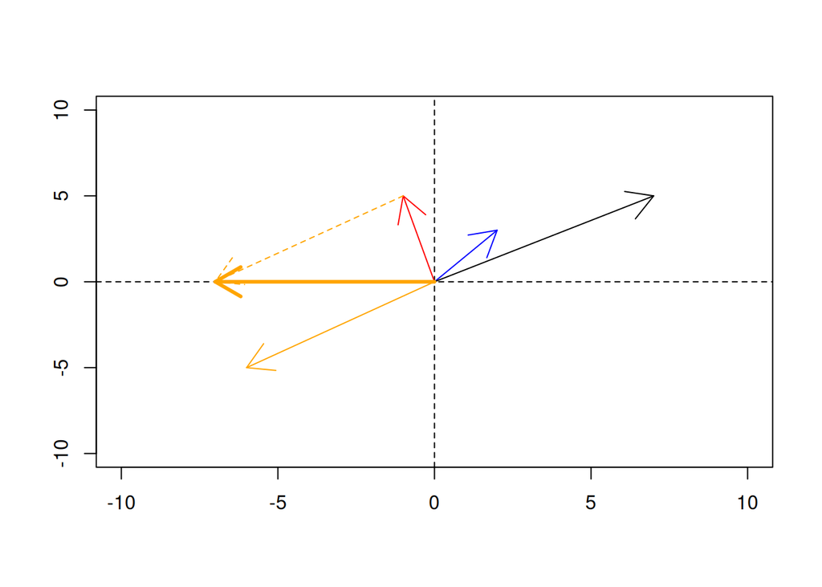

```r
plot(x = c(-10,10), y = c(-10,10), type = "n", xlab = "",ylab = "")
abline(h = 0, lty = 2)
abline(v = 0, lty = 2)
arrows(0,0,-1,5, col = "red")
arrows(0,0,2,3, col = "blue")
arrows(0,0,7,5)
arrows(0,0,-6,-5, col = "orange")
# agrega el vector naranja en la punta del vector rojo
arrows(-1,5,-6-1,5-5, lty = 2, col = "orange")
# agrega el vector suma de los vectores rojo y naranja
arrows(0,0,-6-1,5-5, lwd = 3, col = "orange")
```

## Matrices y sus operaciones

Ejemplos de matrices: diferentes maneras de construir matrices en R:

```r
# matriz con una constante
(A <- matrix(0, nrow = 3, ncol = 4))
```

```
     [,1] [,2] [,3] [,4]
[1,]    0    0    0    0
[2,]    0    0    0    0
[3,]    0    0    0    0
```

```r
A[2,3] # correspnde a la entrada en renglón 2 y col 3
```

```
[1] 0
```

```r
dim(A)
```

```
[1] 3 4
```

```r
# crea una matriz a partir de un vector
b <- c(1,0.7,-0.3,0.7,2,1,-0.3,1,8,0,2,1)
b
```

```
 [1]  1.0  0.7 -0.3  0.7  2.0  1.0 -0.3  1.0  8.0  0.0  2.0  1.0
```

```r
dim(b) <- c(3,4)
b
```

```
     [,1] [,2] [,3] [,4]
[1,]  1.0  0.7 -0.3    0
[2,]  0.7  2.0  1.0    2
[3,] -0.3  1.0  8.0    1
```

```r
dim(b) <- c(4,3) # llena por columna
b
```

```
     [,1] [,2] [,3]
[1,]  1.0  2.0    8
[2,]  0.7  1.0    0
[3,] -0.3 -0.3    2
[4,]  0.7  1.0    1
```

```r
dim(b) <- NULL
b
```

```
 [1]  1.0  0.7 -0.3  0.7  2.0  1.0 -0.3  1.0  8.0  0.0  2.0  1.0
```

```r
# Directamente con la función matriz
B1 <- matrix(c(1,3,5,7,9,11,2,4,6,8,10,12), nrow = 4)
B2 <- matrix(c(1,3,5,7,9,11,2,4,6,8,10,12), nrow = 4, byrow = TRUE)

# Matriz construida a partir de "pegar" vectores
u1 <- 1:10
u2 <- 11:20
u3 <- 21:30

U <- rbind(u1,u2,u3) # Matriz por renglones
W <- cbind(u1,u2,u3) # Matriz por columnas
```

Operaciones con matrices:

```r
A <- matrix(c(3,4,-1,0,2,5), nrow = 2) # 2x3
B <- matrix(c(3,6,4,4,-2,3), nrow = 3) # 3x2
```

```r
# Producto de matrices
A %*% B
```

```
     [,1] [,2]
[1,]   11   20
[2,]   32   31
```

```r
(C <- B %*% A)
```

```
     [,1] [,2] [,3]
[1,]   25   -3   26
[2,]   10   -6    2
[3,]   24   -4   23
```

```r
# Elementos diagonales de C: genera una vector con los elementos diagonales de C

diag(C)
```

```
[1] 25 -6 23
```

```r
# Si se aplica dos veces, crea una matriz diagonal

diag(diag(C))
```

```
     [,1] [,2] [,3]
[1,]   25    0    0
[2,]    0   -6    0
[3,]    0    0   23
```

```r
# Matriz identidad

I <- diag(1, nrow = 3)
A %*% I
```

```
     [,1] [,2] [,3]
[1,]    3   -1    2
[2,]    4    0    5
```

```r
# Matrices triangulares:
C2 <- C
C2[upper.tri(C)] <-0
C2
```

```
     [,1] [,2] [,3]
[1,]   25    0    0
[2,]   10   -6    0
[3,]   24   -4   23
```

```r
# Multiplicar un vector como matriz
b <- 1:3
dim(b) <- c(1,3)
b
```

```
     [,1] [,2] [,3]
[1,]    1    2    3
```

```r
b %*% B
```

```
     [,1] [,2]
[1,]   27    9
```

```r
c <- as.vector(b %*% B)
c
```

```
[1] 27  9
```

```r
# transpuesta
t(A)
```

```
     [,1] [,2]
[1,]    3    4
[2,]   -1    0
[3,]    2    5
```

```r
# inversa
A <- matrix(c(12,-4,7,6), nrow=2)
A
```

```
     [,1] [,2]
[1,]   12    7
[2,]   -4    6
```

```r
A1 <- solve(A) #función inversa
A %*% A1
```

```
             [,1]         [,2]
[1,] 1.000000e+00 8.326673e-17
[2,] 5.551115e-17 1.000000e+00
```

```r
#Podemos redondear
round(A%*% A1,2)
```

```
     [,1] [,2]
[1,]    1    0
[2,]    0    1
```

```r
A1 %*% A
```

```
     [,1]          [,2]
[1,]    1 -5.551115e-17
[2,]    0  1.000000e+00
```

```r
# Determinante (sólo matrices cuadradas)
A <- matrix(c(1,2,3,4), nrow=2)
det(A)
```

```
[1] -2
```

También podemos obtener los eigenvalores y eigenvectores de una matriz (también conocida como valores y vecores propios)

```r
# Ejemplo de matriz de Hilbert de dimensión 3:
H3 <- matrix(c(1, 1/2, 1/3,
               1/2, 1/3, 1/4,
               1/3, 1/4, 1/5),nrow = 3)
H3
```

```
          [,1]      [,2]      [,3]
[1,] 1.0000000 0.5000000 0.3333333
[2,] 0.5000000 0.3333333 0.2500000
[3,] 0.3333333 0.2500000 0.2000000
```

```r
eigen(H3)
```

```
eigen() decomposition
$values
[1] 1.40831893 0.12232707 0.00268734

$vectors
          [,1]       [,2]       [,3]
[1,] 0.8270449  0.5474484  0.1276593
[2,] 0.4598639 -0.5282902 -0.7137469
[3,] 0.3232984 -0.6490067  0.6886715
```

# Sistemas de ecuaciones

Como vieron en las lecciones del módulo, las matrices están muy relacionadas con los sistemas de ecuaciones lineales. Por ejemplo, las ecuaciones:

$$\begin{eqnarray}
x_1 + 3x2 & = & 7 \\
2x_1 + 4x_2 &= & 10
\end{eqnarray}$$

Se puede escribir de la forma:

$$\begin{eqnarray}
\begin{pmatrix} 1 & 3 \\ 2 & 4 \end{pmatrix} \begin{pmatrix} x_1
\\ x_2 \end{pmatrix} & = &
\begin{pmatrix} 7 \\ 10 \end{pmatrix}
\end{eqnarray}$$

```r
A <- matrix(c(1,2,3,4),nrow=2)
b <- c(7,10)
x <- solve(A) %*% b
x
```

```
     [,1]
[1,]    1
[2,]    2
```

Hay tres posibles casos de soluciones para sistemas de ecuaciones:

- Exactamente una solución
- No soluciones
- Infinitas Soluciones

Ver si el siguiente sistema es inconsistente:

$$\begin{eqnarray}
x + y + 2z & = & 3 \\
-x + 3y - 5z & = & 7 \\
2x - 2y + 7z & = & 1 \\
\end{eqnarray}$$

```r
library(matlib) # funciones para resolver sistemas lineales

# Ejemplo de un sistema sin solución
A  <- matrix(c(1, 1, 2, -1, 3, -5, 2, -2, 7), nrow = 3, byrow = T)
b  <- c(3,7,1)
gaussianElimination(A, b)
```

```
     [,1] [,2]  [,3]  [,4]
[1,]    1    0  2.75  4.25
[2,]    0    1 -0.75  3.75
[3,]    0    0  0.00 -5.00
```

La ecuación de abajo nos dice que 0=5, por lo que el sistema no tiene solución

Resolver:

$$\begin{eqnarray}
-x + 2y + 3z & = & 0 \\
x - 4y - 13z & = & 0 \\
-3x + 5y + 4z & = & 0 \\
\end{eqnarray}$$

```r
A <- matrix(c(-1,2,3,1,-4,-13,-3,5,4), nrow = 3, byrow = TRUE)
b <- c(0,0,0)
gaussianElimination(A,b)
```

```
     [,1] [,2] [,3] [,4]
[1,]    1    0    7    0
[2,]    0    1    5    0
[3,]    0    0    0    0
```

¿Cuál es la solución?

```r
A <- matrix(c(1,-1, 2, 0, 3,
             -1, 1, 0, 2,-5,
              1,-1, 4, 2, 4,
             -2, 2,-5,-1,-3), nrow = 4, byrow = TRUE)
b <- c(1,5,13,-1)
gaussianElimination(A,b)
```

```
     [,1] [,2] [,3] [,4] [,5] [,6]
[1,]    1   -1    0   -2    0  -15
[2,]    0    0    1    1    0    5
[3,]    0    0    0    0    1    2
[4,]    0    0    0    0    0    0
```

# Cadenas de Markov

Supongamos un juego con tablero circular con celdas marcadas del 1 al 10. Comenzando con $X_0=1$, se lanza un dado y se avanza ese número de casillas. Sea $X_n=$ número de la casilla en el $n$-ésimo movimiento

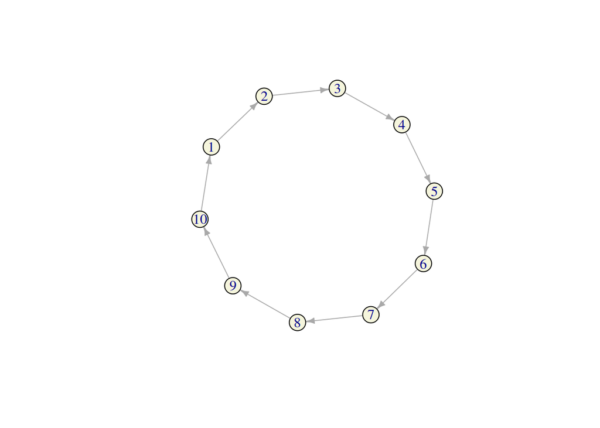

```r
library(igraph)
g <- graph(edges = c(1,2,2,3,3,4,4,5,5,6,6,7,7,8,8,9,9,10,10,1),
           n = 10,
           directed = T)
plot(g, edge.arrow.size = 0.5, vertex.size = 14, vertex.color = "beige")
```

La matriz de probabilidades de transición está dada por:

$$P = \begin{pmatrix}
0 & 1/6 & 1/6 & 1/6 & 1/6 & 1/6 & 1/6 & 0
& 0 & 0 \\
0 & 0 & 1/6 & 1/6 & 1/6 & 1/6 & 1/6 & 1/6
& 0 & 0 \\
0 & 0 & 0 & 1/6 & 1/6 & 1/6 & 1/6 & 1/6
& 1/6 & 0 \\
0 & 0 & 0 & 0 & 1/6 & 1/6 & 1/6 & 1/6 &
1/6 & 1/6 \\
1/6 & 0 & 0 & 0 & 0 & 1/6 & 1/6 & 1/6 &
1/6 & 1/6 \\
1/6 & 1/6 & 0 & 0 & 0 & 0 & 1/6 & 1/6 &
1/6 & 1/6 \\
1/6 & 1/6 & 1/6 & 0 & 0 & 0 & 0 & 1/6 &
1/6 & 1/6 \\
1/6 & 1/6 & 1/6 & 1/6 & 0 & 0 & 0 & 0 &
1/6 & 1/6 \\
1/6 & 1/6 & 1/6 & 1/6 & 1/6 & 0 & 0 & 0
& 0 & 1/6 \\
1/6 & 1/6 & 1/6 & 1/6 & 1/6 & 1/6 & 0 & 0
& 0 & 0
\end{pmatrix}$$

```r
P <- matrix(c(0,rep(c(rep(1/6,6),rep(0,5)),3),
            rep(c(rep(1/6,7),rep(0,4)),6)),nrow=10,byrow=T)
```

Matriz de transición de 2 lanzamientos

```r
P2 <- P %*% P

P3 <- P2 %*% P
```

Creamos una función que pueda hacer el producto de la misma matriz un número $n$ de veces:

```r
simulaciones <- function(n,Q){
  R <- Q
  for(i in 1:n) R <- R %*% Q
  return(R)
}

W <- simulaciones(300,P)  # ejecuta 300 iteraciones del juego.
```

## problema de inventario

Se considera un almacén que tiene un sólo producto y los siguientes supuestos:

- Cuando no hay el producto, las personas va a otro lado.
- Llamamos $X_n$ como el número de artículos en el almacén al inicio del periodo $n$
- El nivel del inventario máximo es 5

Entonces, los posibles niveles del inventario son: 2,3,4 o 5.

```r
library(markovchain)
P <- matrix(c(0.0498,0.1494,0.2240,0.224,
              0,0.0498,0.1494,0.2240,
              0,0,0.0498,0.1494,
              0.9502,0.8008,0.5768,0.4026),nrow= 4)
rownames(P)<- colnames(P) <- as.character(2:5)
inventario <- new("markovchain", states  = as.character(2:5),
                  transitionMatrix = P, name = "Invetario")
steadyStates(inventario)
```

```
            2         3          4        5
[1,] 0.181211 0.1504296 0.09080838 0.577551
```

Una gráfica:

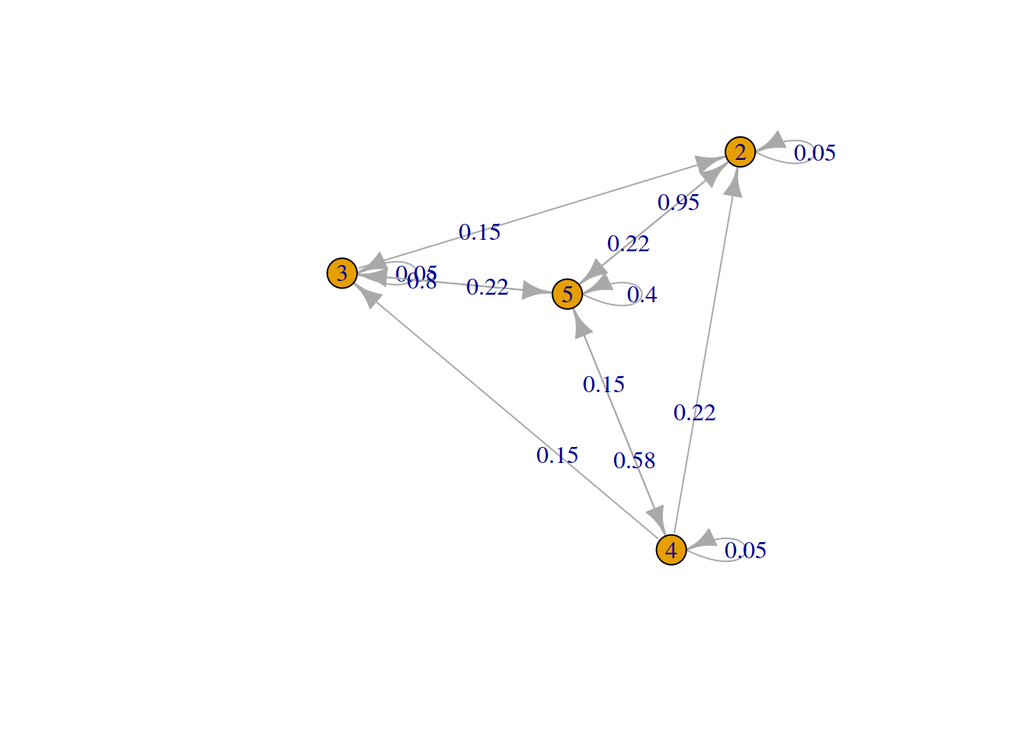

```r
plot(inventario)
```

# Modelos de Insumo-Producto de Leontief

Supongamos una economía particular que depende de petróleo (P), energía (E) y servicios (S). La matriz de insumo-producto de tal economía es:

```r
#Matriz de insumo-producto
A <- matrix(c(0.25,0.15,0.1,0.4,0.15,0.2,0.15,0.2,0.2), nrow=3, byrow=T)
rownames(A) <- colnames(A) <- c("P","E","S")
```

Para interpretar A, por ejemplo, el primer renglón se lee como sigue: Para producir una unidad de petróleo, , la industria del petróleo usa 0.25 unidades de petróleo, 0.15 unidades de energía y 0,1 unidades de servicio.

El vector de producción y el vector de demanda satisfacen la ecuación: $p = Ap+d$ y de aquí obtenemos la relación $p=(I-A)^{-1}d$. La demanda usualmente es conocida, y la producción se obtiene a través de resolver el sistma.

```r
demanda <- c(120,80,100)  # vector de demanda
(produccion <- solve(diag(3) - A) %*% demanda)
```

```
      [,1]
P 244.6220
E 265.0277
S 237.1235
```

Otro ejemplo:

```r
A <- matrix(c(34.69,5.28,10.45,4.92,61.82,25.95,5.62,22.99,42.03),nrow = 3,
            dimnames = list(c("Agricultura","Manufactura","Servicios"),c("Agricultura","Manufactura","Servicios")))
ProduccionTotal <- c(84.56,163.43,219.03)
# se requiere transponer porque apply hace siempre una transpuesta
B <- t(apply(A,1,function(x)x/ProduccionTotal))
demanda <- c(39.24,60.02,130.65)
produccion <- solve(diag(3) - B ) %*% demanda
produccion
```

```
                 [,1]
Agricultura  82.39173
Manufactura 138.83789
Servicios   201.55366
```

[Bureau of Economic Analysis](https://www.bea.gov/industry/industry-underlying-estimates): Aquí se pueden consultar algunas matrices de insumo-producto.

# Modelo de portafolios de inversión

Consideremos un portafolio con tres activos, denotados por A, B y C. Supongan que los activos tienen medias y desviaciones estándar dados por los siguientes vector y matriz de datos mensuales.

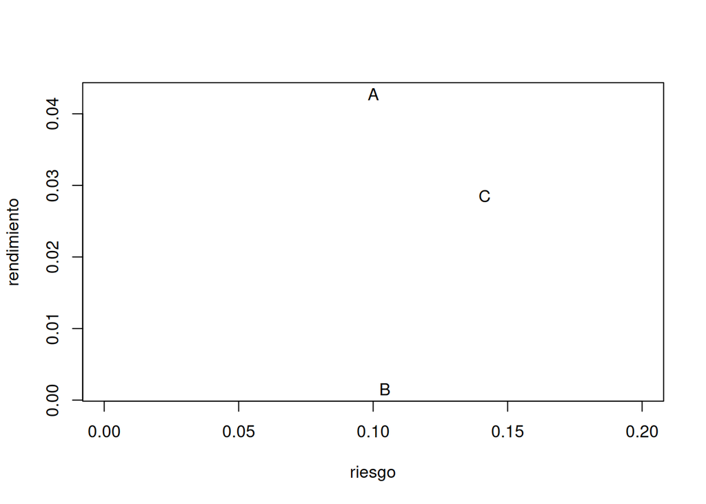

```r
acciones <- c("A","B","C")
rend <- c(0.0427,0.0015,0.0285)
covas <- matrix(c(0.01,0.0018,0.0011,
                  0.0018,0.0109,0.0026,
                  0.0011,0.0026,0.02), nrow = 3)
plot(sqrt(diag(covas)),rend,
     pch = acciones, xlim=c(0,0.2),
     xlab="riesgo", ylab="rendimiento")
```

Supongamos que $x_i$ es la proporción de la riqueza que se invierte en el instrumento $i$.

```r
p1 <- c(0.2,0.5,0.3) # proporciones de inversión
```

El rendimiento y riesgo del portafolio son entonces:

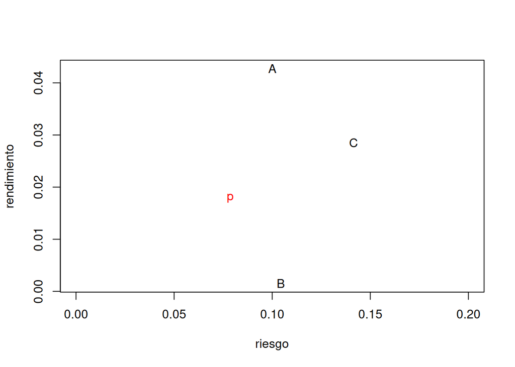

```r
rend_p1 <- producto.punto(p1,rend)
sd_p1 <- as.numeric(sqrt(p1 %*% covas %*% p1))
plot(sqrt(diag(covas)),rend,
     pch = acciones, xlim=c(0,0.2),
     xlab="riesgo", ylab="rendimiento")
points(sd_p1,rend_p1,pch ="p",col="red")
```

Podemos seguir añadiendo portafolios,

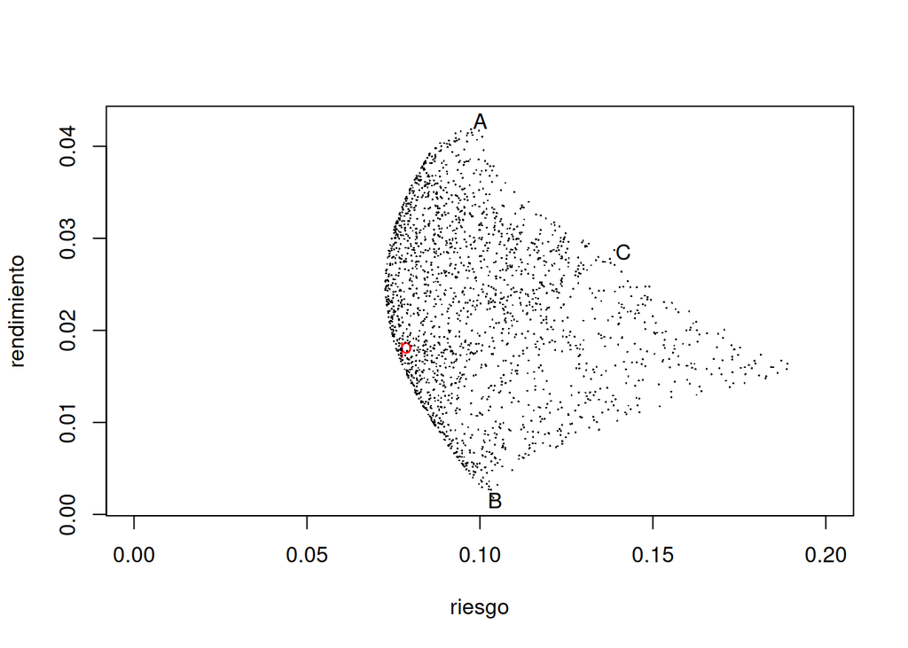

```r
n <- 2000

z <- matrix(0,nrow=n,ncol=3) #matriz de portafolios

z[,1] <- runif(n)
z[,2] <- runif(n)
z[,3] <- 1-z[,1]-z[,2]

# Para cada portafolio calcular su media y su varianza
rend_z <- apply(z,1,function(x)sum(x*rend))
sd_z <- apply(z,1,function(x)as.numeric(sqrt(x %*% covas %*% x)))

plot(sqrt(diag(covas)), rend,
     pch = acciones, xlim=c(0,0.2),
     xlab="riesgo", ylab = "rendimiento")

points(sd_p1,rend_p1,pch ="p",col = "red")
points(sd_z, rend_z, pch = 16, cex = 0.2)
```

- Otras funciones importantes que se aplican a las matrices y a los data frames: `apply`, `tapply`. Más adelante veremos otros ejemplos de este tipo de funciones, que son `lapply`, `sapply` y `mapply`.
- Ejemplos de modelo de Leontief de Insumo-Producto
- Modelo de portafolios de Markowitz
- Otros ejemplos de cadenas de Markov (si da tiempo)

# Otras funciones poderosas para matrices

## Función apply

Esta función permite aplicar alguna función a una matriz ya sea por renglones o por columnas

```r
set.seed(1) #fijar la semilla de números aleatorios
X <- matrix(sample(x = 1:20, size = 20, replace = F),nrow=5)
apply(X,MARGIN = 1,mean) #calcula los promedios de cada renglón
```

```
[1] 14.00  8.75  9.25 13.00  7.50
```

```r
apply(X,MARGIN = 2,max)  #calcular el máximo de cada columna
```

```
[1] 13 19 18 20
```

```r
Y <- cbind(X,apply(X,MARGIN = 1,sum))
colnames(Y) <- c("A","B","C","D","Total")
```

## Función tapply

La función `tapply` permite aplicar una función a un vector, por grupos indicados por una o varias variables que etiquetan a los grupos.

```r
y <- sample(1:100,50,F)
etiquetas <- rep(c("A","B","C","D"),c(20,10,5,15))
tapply(y,etiquetas,function(x)max(x)-min(x))
```

```
 A  B  C  D
80 82 63 81
```

## Ejemplo grandote: Asegurados del IMSS

Veamos los datos de los asegurados por Entidad Federativa al mes de agosto de 2020. Los datos se encuentran en los datos del curso, pero se pueden bajar directamente de la página del IMSS. La ubicación del archivo está en http://datos.imss.gob.mx/sites/default/files/asg-2020-08-31.csv. Adicionalmente, para entender la estructura de datos, se requiere estudiar el diccionario de datos que se encuentra en la siguiente ubicación: http://datos.imss.gob.mx/sites/default/files/diccionario_de_datos_1.xlsx:

```r
# file.choose()`
datos <- read.delim(file = "~/Dropbox/Diplomado de Matemáticas y Estadística 2022/Presentaciones/0. Introducción y manejo del lenguaje R/datos/asg-2020-08-31.csv",
                    fileEncoding = "ISO-8859-1",
                    sep = "|")
```

Este conjunto de datos NO es una matriz, sino un *data.frame*, pues tiene algunas columnas que no son múmeros, sino etiquetas, por ejemplo, las claves de los municipios. Vamos a formar una matriz tomando algunos campos numéricos y viendo cómo aplicar algunas funciones.

Del diccionario de datos, vemos las siguientes definiciones:

- `sexo`: variable que indica si es hombre (1) o mujer (2). Aunque es numérica, en realidad es una etiqueta
- `cve_entidad`: identificador de la Entidad Federativa. Aunque es numérica, es una etiqueta.
- `asegurados`: Número de asegurados.
- `no_trabajadores`: Asegurados sin un empleo asociado
- `teu`: puestos de trabajo eventuales urbanos
- `tec`: puestos de trabajo eventuales del campo
- `tpu`: puestos de trabajo permanentes urbanos
- `tpc`: puestos de trabajo permanentes del campo

```r
sexo <- datos$sexo
entidad <- datos$cve_entidad
asegurados <- datos[,c("asegurados","no_trabajadores")]
puestos_trabajo <- datos[,c("teu","tec","tpu","tpc")]
head(puestos_trabajo,20) #muestra los primeros 20 renglones
```

```
   teu tec tpu tpc
1    0   0   0   0
2    0   0   0   0
3    0   0   0   0
4    0   0   0   0
5    0   0   0   0
6    0   0   0   0
7    0   0   0   0
8    0   0   0   0
9    0   0   0   0
10   0   0   0   0
11   0   0   0   0
12   0   0   0   0
13   0   0   0   0
14   0   0   0   0
15   0   0   0   0
16   0   0   0   0
17   0   0   0   0
18   0   0   0   0
19   0   0   0   0
20   0   0   0   0
```

¿Cómo obtenemos el total de puestos de trabajo?

```r
Total_puestos_trabajo <- apply(puestos_trabajo, 2, sum)
```

Si queremos obtener el total de trabajos por entidad federativa y también separado por hombres y mujeres?

```r
total_por_delegacion <- apply(puestos_trabajo, 1, sum)
# el paréntesis externo es para que imprima el resultado en pantalla cuando termina
(puestos_por_entidad <- tapply(total_por_delegacion,entidad,sum))
```

```
      1       2       3       4       5       6       7       8       9      10
 323153  915557  167538  123878  750871  133853  218178  897690 3251617  236944
     11      12      13      14      15      16      17      18      19      20
 973738  144572  218985 1758496 1586644  448497  201939  143936 1589977  206982
     21      22      23      24      25      26      27      28      29      30
 586731  587463  356310  436384  529692  601240  171299  665498   99667  715225
     31      32
 360933  184855
```

```r
(puestos_por_entidad_y_sexo <- tapply(total_por_delegacion,list(entidad,sexo),sum))
```

```
         1       2
1   204040  119113
2   537487  378070
3   107856   59682
4    85227   38651
5   486503  264368
6    82799   51054
7   137553   80625
8   528380  369310
9  1902545 1349072
10  152374   84570
11  605463  368275
12   89447   55125
13  138788   80197
14 1068525  689971
```

[output cut: 18 more lines]

Si queremos ver los resultados en miles, tenemos que dividir cada renglón por 1000:

```r
(puestos_por_entidad_y_sexo <- tapply(total_por_delegacion,list(entidad,sexo),
                                      function(x)sum(x)/1000))
```

```
          1        2
1   204.040  119.113
2   537.487  378.070
3   107.856   59.682
4    85.227   38.651
5   486.503  264.368
6    82.799   51.054
7   137.553   80.625
8   528.380  369.310
9  1902.545 1349.072
10  152.374   84.570
11  605.463  368.275
12   89.447   55.125
13  138.788   80.197
14 1068.525  689.971
```

[output cut: 18 more lines]